# Apps Focal Landscape

## Existing Vegetation Types-top 10 for the area of interest

[figure not shown]

**NOTE: In chart below the colors match the Biophysical Settings chart when names are exacly the same. Non-matching names will display grey bars.**

## Map of Historical and Existing Vegetation Types

- Zoom into area of interest
- Toggle layers with control in top left corner
- Hover over hex to get vegetation type
- Map for exploratory work only-BpS and EVT legends and mapping methods differ making exact comparisons dicey.
- Hexagons are ~ 5km<sup>2</sup> (1,100ac<sup>2</sup>)

[interactive chart not shown]

## Vegetation Departure

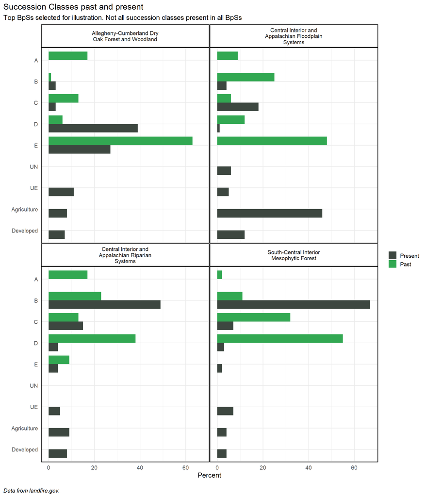